# Evaluation of KNN classifier with Principal Component Analysis

Matteo Fasulo, Simone Flavio Paris, Matteo Sivoccia

07/12/2021

Packages used:

```r
source("https://raw.githubusercontent.com/MatteoFasulo/Rare-Earth/main/R/util/coreFunctions.R")
loadPackages(c('pacman','ggplot2','sn','corrplot','FactoMineR','factoextra','caret','tidyverse'))
pacman::p_loaded()
```

```
 [1] "forcats"    "stringr"    "dplyr"      "purrr"      "readr"      "tidyr"
 [7] "tibble"     "tidyverse"  "caret"      "lattice"    "factoextra" "FactoMineR"
[13] "corrplot"   "sn"         "ggplot2"    "pacman"
```

```r
data(wines)
```

# 1 Dataset

Riassunto del dataset:

```r
wines
```

|  | wine | alcohol | sugar | acidity | tartaric | malic | uronic | pH | ash | alcal_ash | potassium | calcium | magnesium | phosphate | chloride | phenols | flavanoids | nonflavanoids | proanthocyanins | colour | hue | OD_dw | OD_fl | glycerol | butanediol | nitrogen | proline | methanol |
| --- | --- | --- | --- | --- | --- | --- | --- | --- | --- | --- | --- | --- | --- | --- | --- | --- | --- | --- | --- | --- | --- | --- | --- | --- | --- | --- | --- | --- |
| OLO0171 | Barolo | 14.23 | 24.82 | 73.1 | 1.21 | 1.71 | 0.72 | 3.38 | 2.43 | 15.6 | 950 | 62 | 127 | 320 | 82 | 2.80 | 3.06 | 0.28 | 2.29 | 5.640000 | 1.040 | 3.92 | 4.77 | 9.290000 | 757 | 153 | 1065 | 113 |
| OLO0271 | Barolo | 13.20 | 26.30 | 72.8 | 1.84 | 1.78 | 0.71 | 3.30 | 2.14 | 11.2 | 765 | 75 | 100 | 395 | 90 | 2.65 | 2.76 | 0.26 | 1.28 | 4.380000 | 1.050 | 3.40 | 3.80 | 8.930000 | 881 | 194 | 1050 | 94 |
| OLO0371 | Barolo | 13.16 | 26.30 | 68.5 | 1.94 | 2.36 | 0.84 | 3.48 | 2.67 | 18.6 | 936 | 70 | 101 | 497 | 67 | 2.80 | 3.24 | 0.30 | 2.81 | 5.680000 | 1.030 | 3.17 | 3.46 | 11.740000 | 900 | 206 | 1185 | 125 |
| OLO0471 | Barolo | 14.37 | 25.85 | 74.9 | 1.59 | 1.95 | 0.72 | 3.43 | 2.50 | 16.8 | 985 | 47 | 113 | 580 | 49 | 3.85 | 3.49 | 0.24 | 2.18 | 7.800000 | 0.860 | 3.45 | 3.54 | 10.130000 | 1119 | 292 | 1480 | 80 |
| OLO0571 | Barolo | 13.24 | 26.05 | 83.5 | 1.30 | 2.59 | 1.10 | 3.42 | 2.87 | 21.0 | 1088 | 70 | 118 | 408 | 65 | 2.80 | 2.69 | 0.39 | 1.82 | 4.320000 | 1.040 | 2.93 | 3.22 | 10.270000 | 799 | 215 | 735 | 73 |
| OLO0671 | Barolo | 14.20 | 28.40 | 79.9 | 2.14 | 1.76 | 0.96 | 3.39 | 2.45 | 15.2 | 868 | 71 | 112 | 418 | 58 | 3.27 | 3.39 | 0.34 | 1.97 | 6.750000 | 1.050 | 2.85 | 3.16 | 10.850000 | 865 | 364 | 1450 | 68 |
| OLO0771 | Barolo | 14.39 | 27.02 | 64.3 | 1.64 | 1.87 | 0.95 | 3.42 | 2.45 | 14.6 | 889 | 67 | 96 | 306 | 52 | 2.50 | 2.52 | 0.30 | 1.98 | 5.250000 | 1.020 | 3.58 | 3.94 | 9.050000 | 931 | 378 | 1290 | 80 |
| OLO0871 | Barolo | 14.06 | 26.40 | 73.5 | 1.33 | 2.15 | 1.14 | 3.54 | 2.61 | 17.6 | 894 | 50 | 121 | 502 | 64 | 2.60 | 2.51 | 0.31 | 1.25 | 5.050000 | 1.060 | 3.58 | 3.94 | 10.130000 | 865 | 358 | 1295 | 100 |
| OLO0971 | Barolo | 14.83 | 26.80 | 69.5 | 1.82 | 1.64 | 0.67 | 3.30 | 2.17 | 14.0 | 765 | 49 | 97 | 440 | 58 | 2.80 | 2.98 | 0.29 | 1.98 | 5.200000 | 1.080 | 2.85 | 3.03 | 9.890001 | 825 | 438 | 1045 | 141 |
| OLO1071 | Barolo | 13.86 | 27.00 | 68.5 | 1.92 | 1.35 | 0.67 | 3.27 | 2.27 | 16.0 | 794 | 51 | 98 | 391 | 64 | 2.98 | 3.15 | 0.22 | 1.85 | 7.220000 | 1.010 | 3.55 | 3.75 | 12.650000 | 788 | 350 | 1045 | 121 |

[output cut: 168 more lines]

# 2 Correlation Matrix

Abbiamo deciso, per prima cosa, di controllare la correlazione tra le variabili attraverso una rappresentazione grafica dove sia l’intensità del colore che il raggio di ogni circonferenza è proporzionale alla correlazione della variabile.

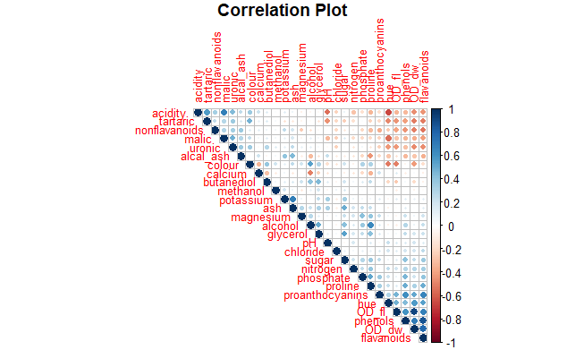

```r
corMatrix <- cor(wines[,-1])
plotCorr <- function(corMatrix){
  col <- colorRampPalette(c("#BB4444", "#EE9988", "#FFFFFF", "#77AADD", "#4477AA"))
  return(corrplot(corMatrix,
                  type="upper",
                  order="FPC",
                  sig.level = 0.01,
                  insig = "blank",
                  title = 'Correlation Plot',
                  tl.cex = .8,
                  mar=c(0,0,1,0)))
}
plotCorr(corMatrix)
```

Ci è sembrato opportuno nella nostra analisi considerare anche l’annata del vino ottenuta dalla trasformazione del nome di ogni osservazione.

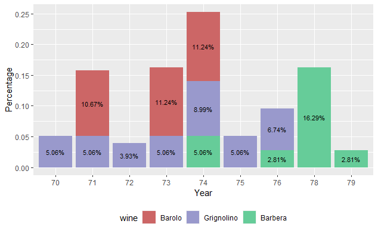

```r
year <- as.numeric(substr(rownames(wines), 6, 7))
wines[,'year'] <- year

wines %>%
    count(wine = factor(wine),
          year = factor(year)) %>%
    mutate(pct = prop.table(n)) %>%
    ggplot(aes(x = year, y = pct, fill = wine, label = scales::percent(pct))) +
    geom_col(position = 'stack') +
    geom_text(position = position_stack(vjust = 0.5),
              size = 3) +
    scale_y_continuous(name = "Percentage")+
    scale_x_discrete(name = "Year")+
    scale_fill_manual(values=c("#CC6666", "#9999CC", "#66CC99"))+
    theme(legend.position = "bottom")
```

# 3 PCA

Utilizzando la Principal Component Analysis abbiamo stimato le componenti principali che descrivono il nostro dataset, con l’aggiunta di 2 variaibli qualitative di supporto:

- Tipo di vino (Barolo, Barbera, Grignolino)
- Annata del vino

## 3.1 Screeplot

Dallo screeplot è possibile visualizzare la percentuale di varianza spiegata dalle componenti principali. Si noti come solamente le prime 2 costituiscono il 41% della varianza totale.

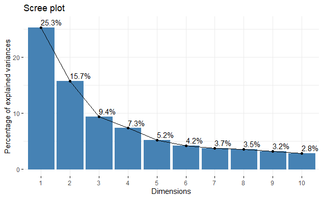

```r
fviz_screeplot(res, addlabels = TRUE, ylim = c(0, 26))
```

Riassunto dell’analisi delle componenti principali:

```r
summary(res, nbelements=10)
```

```
Call:
PCA(X = wines, quanti.sup = NULL, quali.sup = c(1, 29))


Eigenvalues
                       Dim.1   Dim.2   Dim.3   Dim.4   Dim.5   Dim.6   Dim.7   Dim.8   Dim.9
Variance               6.832   4.251   2.528   1.978   1.393   1.125   1.002   0.950   0.853
% of var.             25.303  15.746   9.363   7.325   5.160   4.167   3.713   3.519   3.159
Cumulative % of var.  25.303  41.049  50.412  57.737  62.897  67.065  70.778  74.296  77.455
                      Dim.10  Dim.11  Dim.12  Dim.13  Dim.14  Dim.15  Dim.16  Dim.17  Dim.18
Variance               0.754   0.725   0.639   0.541   0.478   0.439   0.379   0.340   0.320
% of var.              2.792   2.686   2.365   2.003   1.772   1.626   1.403   1.259   1.185
Cumulative % of var.  80.247  82.933  85.298  87.301  89.073  90.700  92.103  93.362  94.548
                      Dim.19  Dim.20  Dim.21  Dim.22  Dim.23  Dim.24  Dim.25  Dim.26  Dim.27
Variance               0.276   0.243   0.214   0.200   0.165   0.132   0.109   0.081   0.050
% of var.              1.020   0.900   0.794   0.741   0.613   0.490   0.405   0.301   0.187
Cumulative % of var.  95.568  96.469  97.263  98.004  98.617  99.107  99.512  99.813 100.000

Individuals (the 10 first)
                    Dist    Dim.1    ctr   cos2    Dim.2    ctr   cos2    Dim.3    ctr   cos2
OLO0171         |  5.090 |  3.641  1.090  0.512 |  0.631  0.053  0.015 | -0.125  0.003  0.001
OLO0271         |  4.163 |  2.447  0.492  0.346 | -0.359  0.017  0.007 | -2.206  1.082  0.281
OLO0371         |  4.646 |  2.969  0.725  0.408 |  2.191  0.634  0.222 |  0.671  0.100  0.021
OLO0471         |  6.663 |  4.185  1.440  0.394 |  3.848  1.956  0.334 | -0.766  0.131  0.013
OLO0571         |  4.148 |  1.385  0.158  0.111 |  1.603  0.339  0.149 |  2.452  1.336  0.349
OLO0671         |  5.185 |  3.116  0.798  0.361 |  2.902  1.113  0.313 | -0.943  0.198  0.033
OLO0771         |  4.852 |  2.991  0.735  0.380 |  1.365  0.246  0.079 | -0.412  0.038  0.007
OLO0871         |  5.054 |  3.030  0.755  0.359 |  2.494  0.822  0.243 |  0.469  0.049  0.009
OLO0971         |  5.294 |  3.114  0.798  0.346 |  1.631  0.351  0.095 | -2.180  1.056  0.170
OLO1071         |  4.870 |  3.448  0.978  0.501 |  1.591  0.335  0.107 | -1.542  0.528  0.100

OLO0171         |
OLO0271         |
OLO0371         |
OLO0471         |
OLO0571         |
OLO0671         |
OLO0771         |
OLO0871         |
OLO0971         |
```

[output cut: 23 more lines]

```
year.73         |   2.070 |   1.658   0.641   3.723 |  -0.157   0.006  -0.447 |   0.859
year.74         |   0.907 |   0.680   0.561   2.012 |  -0.150   0.027  -0.564 |  -0.292
year.75         |   2.976 |   0.101   0.001   0.118 |  -2.139   0.516  -3.185 |   1.064
year.76         |   2.357 |  -0.942   0.160  -1.558 |  -0.900   0.146  -1.886 |   1.286
                   cos2  v.test
Barolo            0.012  -2.002 |
Grignolino        0.029   2.511 |
Barbera           0.001  -0.647 |
year.70           0.225  -3.104 |
year.71           0.064  -2.389 |
year.72           0.014   0.467 |
year.73           0.172   3.171 |
year.74           0.103  -1.419 |
year.75           0.128   2.054 |
year.76           0.298   3.497 |
```

## 3.2 Individuals Plot

La libreria *fviz* ci ha permesso di rappresentare graficamente gli individui in funzione delle prime due componenti principali. Per semplicità di rappresentazione, vengono mostrati gli individui il cui cos2 è maggiore di 0.6 .

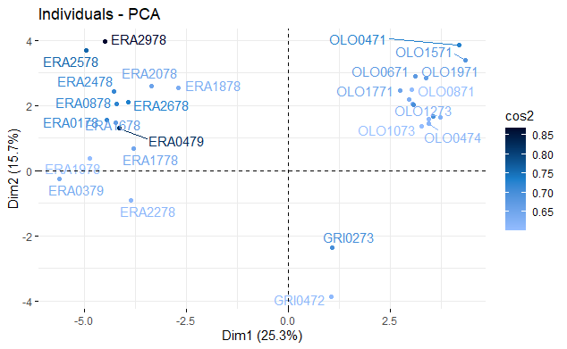

```r
fviz_pca_ind(res,
             col.ind="cos2",
             geom = c("point","text"),
             gradient.cols = c("#94bdff","#1b7fcc",'#00062e'),
             repel=T,
             select.ind= list(cos2 = .6),
             ggtheme=theme_minimal())
```

## 3.3 Variables Plot

Discorso analogo per quanto riguarda le variabili, selezionando le top 10 per cos2.

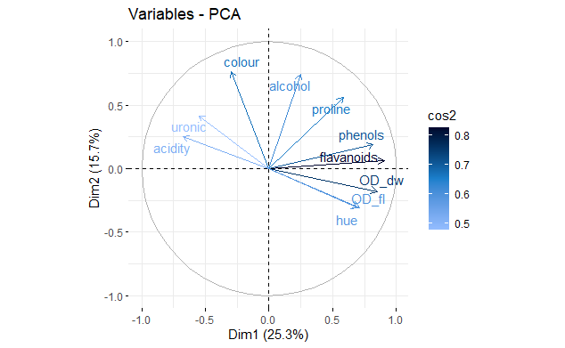

```r
fviz_pca_var(res, col.var = "cos2",
             gradient.cols = c("#94bdff","#1b7fcc",'#00062e'),
             select.var= list(cos2 = 10),
             repel = T,
             ggtheme = theme_minimal())
```

## 3.4 BiPlot

Combinando insieme le due precedenti rappresentazioni:

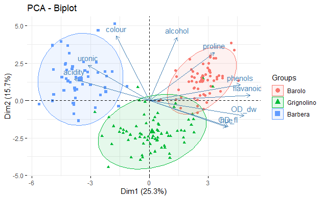

```r
fviz_pca_biplot(res, label = "var", habillage=wines$wine,
                addEllipses=TRUE, ellipse.level=0.90,
                ggtheme = theme_minimal(),
                select.var= list(cos2 = 10))
```

## 3.5 Ellipses Plot

Considerando inoltre il fattore annata del vino:

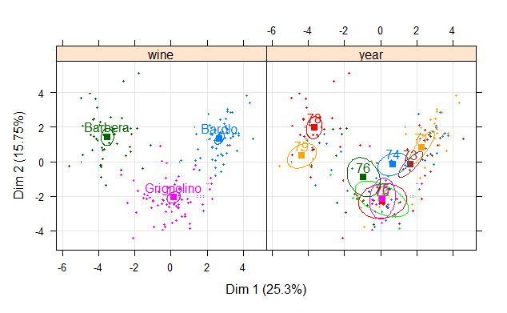

```r
plotellipses(model=res, autoLab = "auto")
```

## 3.6 What about 3rd and 4th dimension?

Per scrupolo, abbiamo controllato anche le componenti principali successive alla prima e seconda dimensione, notando che le osservazioni, sulla terza e quarta dimensione, non sono ben distinguibili.

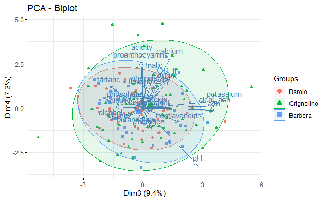

```r
fviz_pca_biplot(res, axes=c(3,4), label = "var", habillage=wines$wine,
                addEllipses=TRUE, ellipse.level=0.90,
                ggtheme = theme_minimal())
```

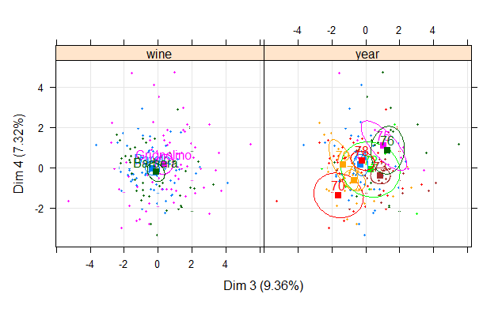

```r
plotellipses(model=res, axes=c(3,4), autoLab = "auto")
```

# 4 Splitting (using caret)

Volendo dunque utilizzare le componenti principali come base per una classificazione, abbiamo recuperato gli score per ogni osservazione dalle due dimensioni (DIM1 e DIM2), e diviso il dataset originario in una sezione di training ed una di testing. Lo split è effettuato secondo una proporzione di 0.7:

```r
set.seed(3033)
intrain <- createDataPartition(y = wines$wine, p=0.7, list = FALSE)
dim(intrain)
```

```
[1] 126   1
```

# 5 KNN

Combinando in un unico dataframe i risultati della prima e della seconda componente principale è stato possibile applicare, tra i tanti metodi di classificazione, il KNN (K Nearest Neighbours) con Cross Validation 10-Fold:

```r
pc.comp <- res$ind$coord
pc.comp1 <- pc.comp[,1]
pc.comp2 <- pc.comp[,2]
X = cbind(pc.comp1, pc.comp2)
X = as.data.frame(cbind(wine=wines$wine, X))
X[which(X$wine==1),1] <- "Barolo"
X[which(X$wine==2),1] <- "Grignolino"
X[which(X$wine==3),1] <- "Barbera"
```

## 5.1 KNN-PC1

```r
trctrl <- trainControl(method = "repeatedcv", number = 10, repeats = 3)
set.seed(3333)
knn_fit.PC1 <- caret::train(wine ~ .-pc.comp2, data = X[intrain,], method = "knn",
                 trControl=trctrl,
                 preProcess = c("center", "scale"),
                 tuneLength = 10)
print(knn_fit.PC1)
```

```
k-Nearest Neighbors

126 samples
  2 predictor
  3 classes: 'Barbera', 'Barolo', 'Grignolino'

Pre-processing: centered (1), scaled (1)
Resampling: Cross-Validated (10 fold, repeated 3 times)
Summary of sample sizes: 113, 113, 113, 114, 113, 114, ...
Resampling results across tuning parameters:

  k   Accuracy   Kappa
   5  0.8703602  0.8039569
   7  0.8917277  0.8366649
   9  0.8770452  0.8144087
  11  0.8426435  0.7616690
  13  0.8590965  0.7857366
  15  0.8590965  0.7858118
  17  0.8642247  0.7931839
  19  0.8670024  0.7974822
  21  0.8697802  0.8017823
  23  0.8618742  0.7900367

Accuracy was used to select the optimal model using the largest value.
The final value used for the model was k = 7.
```

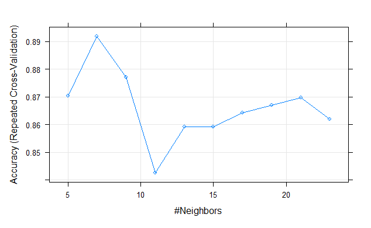

```r
plot(knn_fit.PC1)
```

```r
test_pred <- predict(knn_fit.PC1, newdata = X[-intrain,])
confusionMatrix(test_pred, as.factor(X[-intrain,'wine']))
```

```
Confusion Matrix and Statistics

            Reference
Prediction   Barbera Barolo Grignolino
  Barbera         11      0          1
  Barolo           0     15          4
  Grignolino       3      2         16

Overall Statistics

               Accuracy : 0.8077
                 95% CI : (0.6747, 0.9037)
    No Information Rate : 0.4038
    P-Value [Acc > NIR] : 3.066e-09

                  Kappa : 0.7065

 Mcnemar's Test P-Value : NA

Statistics by Class:

                     Class: Barbera Class: Barolo Class: Grignolino
Sensitivity                  0.7857        0.8824            0.7619
Specificity                  0.9737        0.8857            0.8387
Pos Pred Value               0.9167        0.7895            0.7619
Neg Pred Value               0.9250        0.9394            0.8387
Prevalence                   0.2692        0.3269            0.4038
Detection Rate               0.2115        0.2885            0.3077
Detection Prevalence         0.2308        0.3654            0.4038
Balanced Accuracy            0.8797        0.8840            0.8003
```

## 5.2 KNN-PC2

```r
trctrl <- trainControl(method = "repeatedcv", number = 10, repeats = 3)
set.seed(3333)
knn_fit.PC2 <- caret::train(wine ~ .-pc.comp1, data = X[intrain,], method = "knn",
                 trControl=trctrl,
                 preProcess = c("center", "scale"),
                 tuneLength = 10)
print(knn_fit.PC2)
```

```
k-Nearest Neighbors

126 samples
  2 predictor
  3 classes: 'Barbera', 'Barolo', 'Grignolino'

Pre-processing: centered (1), scaled (1)
Resampling: Cross-Validated (10 fold, repeated 3 times)
Summary of sample sizes: 113, 113, 113, 114, 113, 114, ...
Resampling results across tuning parameters:

  k   Accuracy   Kappa
   5  0.6830281  0.5153037
   7  0.6549145  0.4722291
   9  0.6345849  0.4433136
  11  0.6361111  0.4451775
  13  0.6517399  0.4674850
  15  0.6630647  0.4828575
  17  0.6713370  0.4949639
  19  0.6841880  0.5134491
  21  0.6743284  0.4968853
  23  0.6794872  0.5041481

Accuracy was used to select the optimal model using the largest value.
The final value used for the model was k = 19.
```

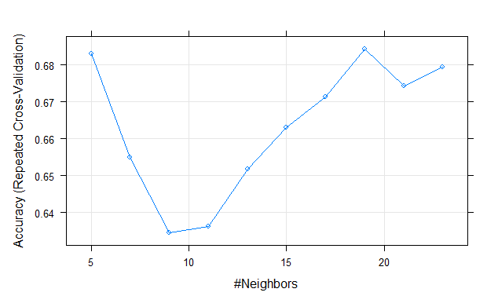

```r
plot(knn_fit.PC2)
```

```r
test_pred <- predict(knn_fit.PC2, newdata = X[-intrain,])
confusionMatrix(test_pred, as.factor(X[-intrain,'wine']))
```

```
Confusion Matrix and Statistics

            Reference
Prediction   Barbera Barolo Grignolino
  Barbera          3      5          0
  Barolo           9     11          2
  Grignolino       2      1         19

Overall Statistics

               Accuracy : 0.6346
                 95% CI : (0.4896, 0.7638)
    No Information Rate : 0.4038
    P-Value [Acc > NIR] : 0.0006539

                  Kappa : 0.4374

 Mcnemar's Test P-Value : 0.3238633

Statistics by Class:

                     Class: Barbera Class: Barolo Class: Grignolino
Sensitivity                 0.21429        0.6471            0.9048
Specificity                 0.86842        0.6857            0.9032
Pos Pred Value              0.37500        0.5000            0.8636
Neg Pred Value              0.75000        0.8000            0.9333
Prevalence                  0.26923        0.3269            0.4038
Detection Rate              0.05769        0.2115            0.3654
Detection Prevalence        0.15385        0.4231            0.4231
Balanced Accuracy           0.54135        0.6664            0.9040
```

## 5.3 KNN-PC1+PC2

```r
trctrl <- trainControl(method = "repeatedcv", number = 10, repeats = 3)
set.seed(3333)
knn_fit.PC12 <- caret::train(wine ~ ., data = X[intrain,], method = "knn",
                 trControl=trctrl,
                 preProcess = c("center", "scale"),
                 tuneLength = 10)
print(knn_fit.PC12)
```

```
k-Nearest Neighbors

126 samples
  2 predictor
  3 classes: 'Barbera', 'Barolo', 'Grignolino'

Pre-processing: centered (2), scaled (2)
Resampling: Cross-Validated (10 fold, repeated 3 times)
Summary of sample sizes: 113, 113, 113, 114, 113, 114, ...
Resampling results across tuning parameters:

  k   Accuracy   Kappa
   5  0.9679487  0.9514459
   7  0.9707265  0.9557470
   9  0.9679487  0.9514459
  11  0.9679487  0.9514459
  13  0.9786325  0.9676281
  15  0.9786325  0.9676281
  17  0.9811966  0.9715320
  19  0.9811966  0.9715320
  21  0.9784188  0.9674942
  23  0.9758547  0.9635548

Accuracy was used to select the optimal model using the largest value.
The final value used for the model was k = 19.
```

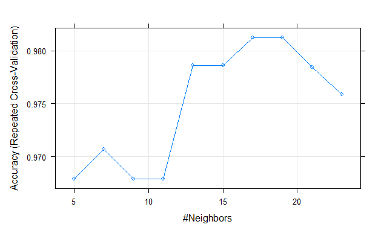

```r
plot(knn_fit.PC12)
```

```r
test_pred <- predict(knn_fit.PC12, newdata = X[-intrain,])
confusionMatrix(test_pred, as.factor(X[-intrain,'wine']))
```

```
Confusion Matrix and Statistics

            Reference
Prediction   Barbera Barolo Grignolino
  Barbera         12      0          2
  Barolo           0     16          2
  Grignolino       2      1         17

Overall Statistics

               Accuracy : 0.8654
                 95% CI : (0.7421, 0.9441)
    No Information Rate : 0.4038
    P-Value [Acc > NIR] : 7.586e-12

                  Kappa : 0.7957

 Mcnemar's Test P-Value : NA

Statistics by Class:

                     Class: Barbera Class: Barolo Class: Grignolino
Sensitivity                  0.8571        0.9412            0.8095
Specificity                  0.9474        0.9429            0.9032
Pos Pred Value               0.8571        0.8889            0.8500
Neg Pred Value               0.9474        0.9706            0.8750
Prevalence                   0.2692        0.3269            0.4038
Detection Rate               0.2308        0.3077            0.3269
Detection Prevalence         0.2692        0.3462            0.3846
Balanced Accuracy            0.9023        0.9420            0.8564
```

## 5.4 KNN (without PCA)

```r
trctrl <- trainControl(method = "repeatedcv", number = 10, repeats = 3)
set.seed(3333)
knn_fit <- train(wine ~.-year, data = wines[intrain,], method = "knn",
                 trControl=trctrl,
                 preProcess = c("center", "scale"),
                 tuneLength = 10)
print(knn_fit)
```

```
k-Nearest Neighbors

126 samples
 28 predictor
  3 classes: 'Barolo', 'Grignolino', 'Barbera'

Pre-processing: centered (27), scaled (27)
Resampling: Cross-Validated (10 fold, repeated 3 times)
Summary of sample sizes: 113, 113, 113, 114, 113, 114, ...
Resampling results across tuning parameters:

  k   Accuracy   Kappa
   5  0.9869658  0.9801365
   7  0.9677350  0.9512990
   9  0.9732906  0.9594734
  11  0.9784188  0.9673896
  13  0.9730769  0.9593443
  15  0.9677350  0.9513867
  17  0.9677350  0.9513867
  19  0.9677350  0.9513867
  21  0.9681319  0.9519910
  23  0.9709096  0.9561577

Accuracy was used to select the optimal model using the largest value.
The final value used for the model was k = 5.
```

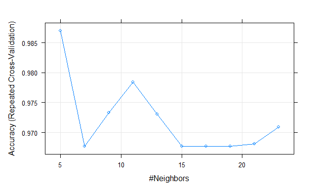

```r
plot(knn_fit)
```

```r
test_pred <- predict(knn_fit, newdata = wines[-intrain,])
confusionMatrix(test_pred, as.factor(wines[-intrain,1]))
```

```
Confusion Matrix and Statistics

            Reference
Prediction   Barolo Grignolino Barbera
  Barolo         17          0       0
  Grignolino      0         21       0
  Barbera         0          0      14

Overall Statistics

               Accuracy : 1
                 95% CI : (0.9315, 1)
    No Information Rate : 0.4038
    P-Value [Acc > NIR] : < 2.2e-16

                  Kappa : 1

 Mcnemar's Test P-Value : NA

Statistics by Class:

                     Class: Barolo Class: Grignolino Class: Barbera
Sensitivity                 1.0000            1.0000         1.0000
Specificity                 1.0000            1.0000         1.0000
Pos Pred Value              1.0000            1.0000         1.0000
Neg Pred Value              1.0000            1.0000         1.0000
Prevalence                  0.3269            0.4038         0.2692
Detection Rate              0.3269            0.4038         0.2692
Detection Prevalence        0.3269            0.4038         0.2692
Balanced Accuracy           1.0000            1.0000         1.0000
```

## 5.5 KNN comparison

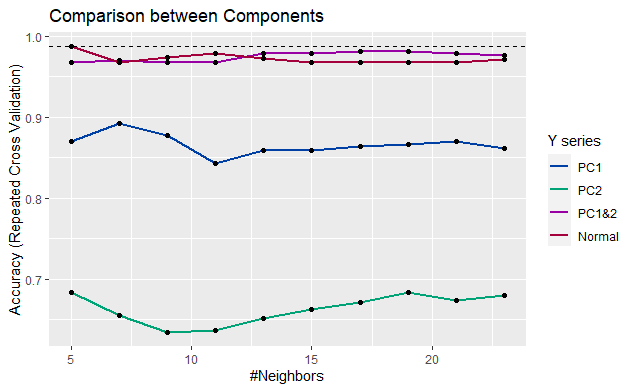

```r
knn.accuracyData = as.data.frame(cbind(PC1 = knn_fit.PC1$results$Accuracy,
                                       PC2 = knn_fit.PC2$results$Accuracy,
                                       PC12= knn_fit.PC12$results$Accuracy,
                                       NO_PCA = knn_fit$results$Accuracy))

ggplot(knn.accuracyData, aes(knn_fit.PC1$results$k)) +
  geom_line(aes(y = PC1, colour = "PC1"), size=0.8) + geom_point(aes(y = PC1)) +
  geom_line(aes(y = PC2, colour = "PC2"), size=0.8) + geom_point(aes(y = PC2)) +
  geom_line(aes(y = PC12, colour = "PC1&2"), size=0.8) + geom_point(aes(y = PC12)) +
  geom_line(aes(y = NO_PCA, colour = "Normal"), size=0.8) + geom_point(aes(y = NO_PCA)) +
  #geom_hline(yintercept=max(knn.accuracyData$PC12), linetype="dashed", size = 0.8) +
  geom_hline(yintercept=max(knn.accuracyData$NO_PCA), linetype="dashed", size = 0.5) +
  scale_color_manual(name = "Y series", values = c("PC1" = "#003fa3", "PC2" = "#00a375", "PC1&2" = "#9800a3", "Normal" = "#a3003c")) +
  ggtitle("Comparison between Components") +
  xlab("#Neighbors") + ylab("Accuracy (Repeated Cross Validation)")
```